# Seazone Code Challenge

Tarcizio Barbosa

11/01/2022

### Load Packages

```r
library(tidyverse)
```

```r
library(corrplot)
```

### Load Databases

```r
price_data <- read.csv("desafio_priceav.csv", encoding = "UTF-8")
details_data <- read.csv("desafio_details.csv", encoding = "UTF-8")
```

- Verifcando os tipos de dados das duas bases.

```r
glimpse(details_data)
```

```
## Rows: 4,691
## Columns: 9
## $ X                   <int> 0, 1, 2, 3, 4, 5, 6, 7, 8, 9, 10, 11, 12, 13, 14, ~
## $ airbnb_listing_id   <int> 31389869, 40010667, 38905997, 22343656, 18328184, ~
## $ suburb              <chr> "Jurerê", "Canasvieiras", "Ingleses", "Ingleses", ~
## $ ad_name             <chr> "Lindo Apartamento em Jurerê", "Residencial Arruda~
## $ number_of_bedrooms  <dbl> 2, 1, 1, 2, 2, 2, 1, 1, 1, 1, 2, 2, NA, 2, 3, 3, 3~
## $ number_of_bathrooms <dbl> 2, 1, 1, 1, 1, 2, 1, 1, 1, 1, 1, 1, 1, 1, 2, 2, 2,~
## $ star_rating         <dbl> 5.0, NA, 4.5, 5.0, 5.0, 5.0, 4.5, 4.5, NA, 4.0, 5.~
## $ is_superhost        <chr> "False", "False", "True", "True", "True", "True", ~
## $ number_of_reviews   <dbl> 15, 0, 13, 28, 35, 62, 32, 3, 0, 16, 12, 0, 6, 0, ~
```

```r
glimpse(price_data)
```

```
## Rows: 354,520
## Columns: 7
## $ X                 <int> 0, 1, 2, 3, 4, 5, 6, 7, 8, 9, 10, 11, 12, 13, 14, 15~
## $ Unnamed..0        <int> 2148, 2159, 2160, 2173, 2226, 2230, 2236, 2245, 2246~
## $ airbnb_listing_id <int> 40201349, 40201349, 40201349, 40201349, 40201349, 40~
## $ booked_on         <chr> "blank", "blank", "blank", "blank", "blank", "blank"~
## $ date              <chr> "2020-11-15", "2020-11-26", "2020-11-27", "2020-12-1~
## $ price_string      <dbl> 250, 250, 250, 250, 250, 250, 250, 250, 250, 250, 25~
## $ occupied          <int> 0, 0, 0, 0, 0, 0, 0, 0, 0, 0, 0, 0, 1, 1, 0, 0, 0, 0~
```

- Verificando a quantidade de bairros únicos dentro da base.

```r
unique(details_data$suburb)
```

```
## [1] "Jurerê"             "Canasvieiras"       "Ingleses"
## [4] "Lagoa da Conceição" "Centro"
```

### Questões

- Questão 1: Ordene os bairros em ordem crescente de número de listings.

O bairro “Ingleses” é o que apresenta maior número de listings.

```r
by_location <- details_data %>% group_by(suburb) %>% summarise(counts = n())

by_location
```

```
## # A tibble: 5 x 2
##   suburb             counts
##   <chr>               <int>
## 1 Canasvieiras         1177
## 2 Centro                278
## 3 Ingleses             2388
## 4 Jurerê                539
## 5 Lagoa da Conceição    309
```

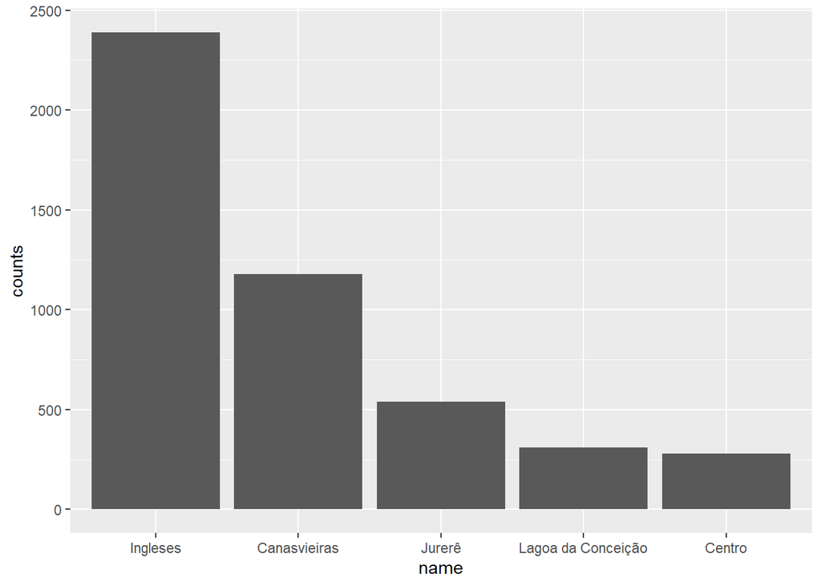

```r
by_location %>%
  mutate(name = fct_reorder(suburb, desc(counts))) %>%
  ggplot(aes(x = name, y = counts)) +
    geom_bar(stat = "identity")
```

- Questão 2: Ordene os bairros em ordem crescente de faturamento médio dos listings.

Como o faturamento e o bairro estão em datasets distintos, realizei um left_join para trazer a informação do faturamento baseado na coluna airbnb_listing_id.

```r
with_suburb <- left_join(details_data, price_data, by = "airbnb_listing_id")

with_suburb$price_string <- as.integer(with_suburb$price_string)
```

Com os dados de faturamento é possível responder a questão. Jurerê apesar de não ter muitos listings, é o que apresenta maior média de faturamento.

```r
by_mean <- with_suburb %>% group_by(suburb) %>% summarise(means = mean(price_string, na.rm = T))

by_mean
```

```
## # A tibble: 5 x 2
##   suburb             means
##   <chr>              <dbl>
## 1 Canasvieiras        293.
## 2 Centro              219.
## 3 Ingleses            350.
## 4 Jurerê              406.
## 5 Lagoa da Conceição  251.
```

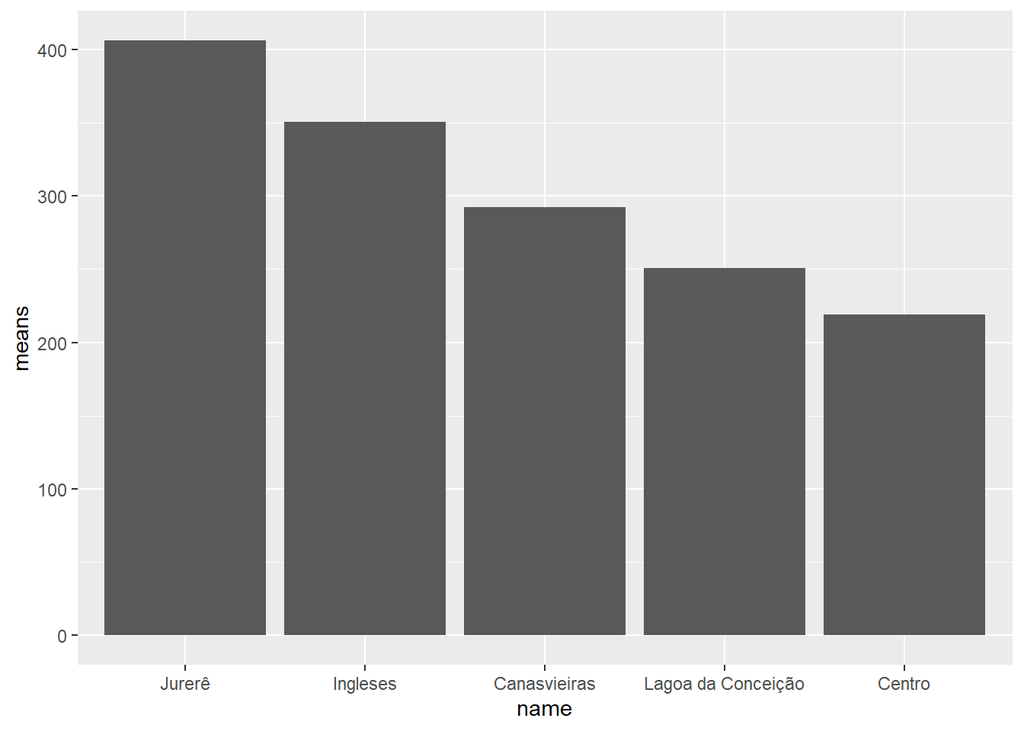

```r
by_mean %>%
  mutate(name = fct_reorder(suburb, desc(means))) %>%
  ggplot(aes(x = name, y = means)) +
    geom_bar(stat = "identity")
```

- Questão 3: Existem correlações entre as características de um anúncio e seu faturamento?

Antes de calcular a correlação, foi removido as linhas com valores NA, até para testar outras correlações.

```r
with_suburb_without_na <- with_suburb[rowSums(is.na(with_suburb)) == 0,]
```

De acordo com o resultado, a correlação entre Faturamento e Avaliação é muito baixa. Bem próxima de zero.

```r
cor(with_suburb_without_na$price_string, with_suburb_without_na$star_rating)
```

```
## [1] 0.06531657
```

Graficamente também não existe nenhum padrão entre estas duas variáveis.

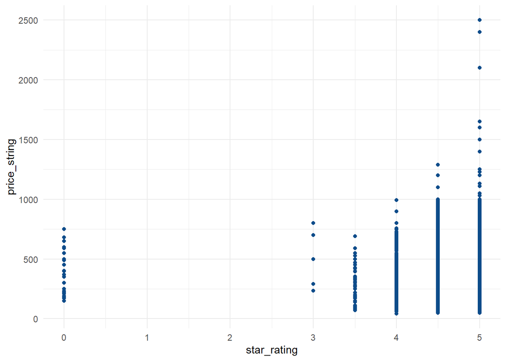

```r
ggplot(with_suburb_without_na) +
  aes(x = star_rating, y = price_string) +
  geom_point(colour = "#0c4c8a") +
  theme_minimal()
```

Porém quando verificamos todas as colunas numéricas, percebemos que existe uma correlação considerável entre número de quartos/banheiros com o preço.

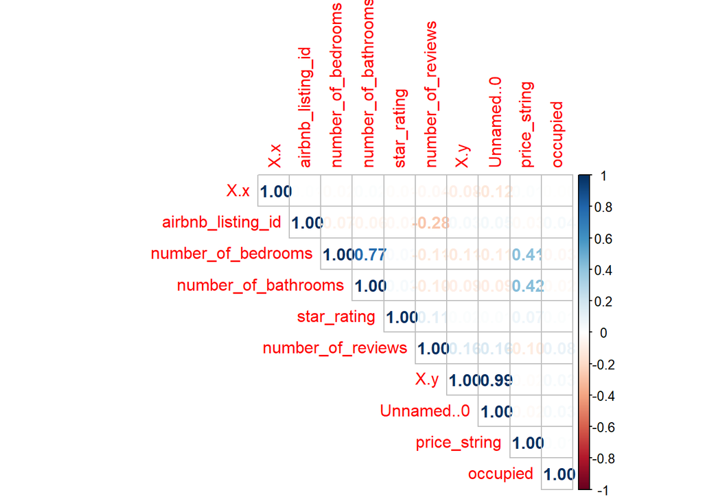

```r
corrplot(cor(select_if(with_suburb_without_na, is.numeric)),
         method = "number",
         type = "upper")
```

- Questão 4: Qual a antecedência média das reservas?

Para esta questão primeiro é necessário transformas a coluna booked_on em date (pois a mesma originalmente é uma string). Posteriormente é criada uma nova coluna com a diferença de dias entre as colunas date e booked_on para verificar a quantidade de dias que antecedem o aluguel.

Assim é possível verificar que a média de antecedência é 1 mês.

```r
with_suburb_without_na$booked_on <- as.Date(with_suburb_without_na$booked_on)

with_suburb_without_na <- mutate(with_suburb_without_na,
                                 days_diff = difftime(date, booked_on, units = "days"))

with_suburb_without_na$days_diff <- as.integer(with_suburb_without_na$days_diff)

mean(with_suburb_without_na$days_diff, na.rm = T)
```

```
## [1] 31.8956
```

Para fazer a verificação para os finais de semana, criou-se uma coluna que identifica o dia da semana, começando na Seg = 1 e indo até o Dom = 7.

Considerei como finais de semana Sab e Dom (6 e 7).

Assim é possível verificar que não existem tanta diferença nas médias de antecedência:

Para finais de semana

```r
is_weekend <- mutate(with_suburb_without_na,
                                 wd = lubridate::wday(date, week_start = 1)) %>% filter(wd == 6 | wd == 7)

mean(is_weekend$days_diff, na.rm = T)
```

```
## [1] 31.63975
```

Para dias da semana.

```r
is_not_weekend <- mutate(with_suburb_without_na,
                                 wd = lubridate::wday(date, week_start = 1)) %>% filter(wd != 6 & wd != 7)

mean(is_not_weekend$days_diff, na.rm = T)
```

```
## [1] 32.00643
```